## Report: act_report

# Which stage of dog is the most popular in the sample data?

### Before we move into our discovery, let's have a more clear understanding of what each dog stage means:

```
1. Pupper: "Pupper" is a colloquial term used to refer to a small or young dog, typically a puppy. It is often associated with dogs in their early stages of life, characterized by their playful and adorable nature.
```

```
2. Doggo: "Doggo" is another slang term used to refer to a dog, typically in a more general sense. It can be used to describe any dog, regardless of age or size. "Doggo" is often used humorously or affectionately in internet memes and social media.
```

```
3. Puppo: "Puppo" is an endearing term used to refer to a dog, specifically emphasizing its cuteness or puppy-like qualities. It is similar to "pupper" but with a more affectionate tone, often used to describe dogs that are particularly adorable or charming.
```

```
4. Floofer: "Floofer" is a term used to describe a dog with long, fluffy fur or hair. It refers to dogs that have abundant, often voluminous, coats of fur that give them a fluffy and huggable appearance. Primarily used to describe a dog based on its physical characteristic of having a thick and fluffy coat.
```

### It's important to note that these terms originated as internet slang and are not widely recognized in formal or official contexts. They have gained popularity through memes, social media, and online dog communities as a way to humorously and affectionately describe different aspects of dogs.

### However, based on the provided sample data from Twitter's WeRateDogs posts, we have been able to derive intriguing insights indicating a higher preference among individuals for small puppies compared to other stages of dogs. The following pie charts illustrate the distribution of dog stages in relation to favorite counts and retweet counts. It is evident that the doggo and pupper stages consistently garner more popularity.

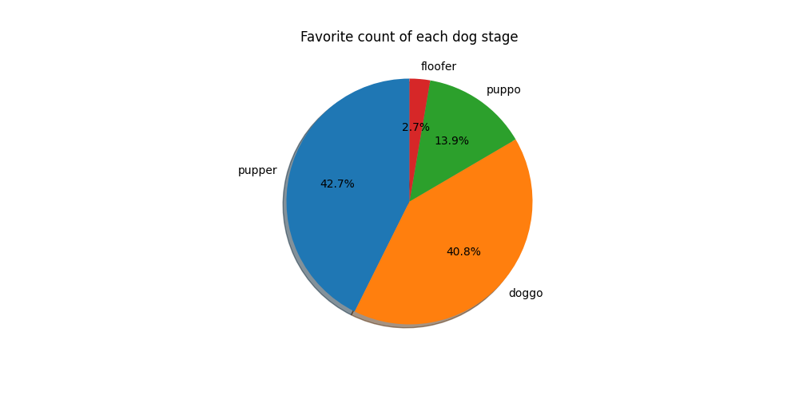

```python
from IPython.display import Image
Image(filename='Favorite count of each dog stage.png')
```

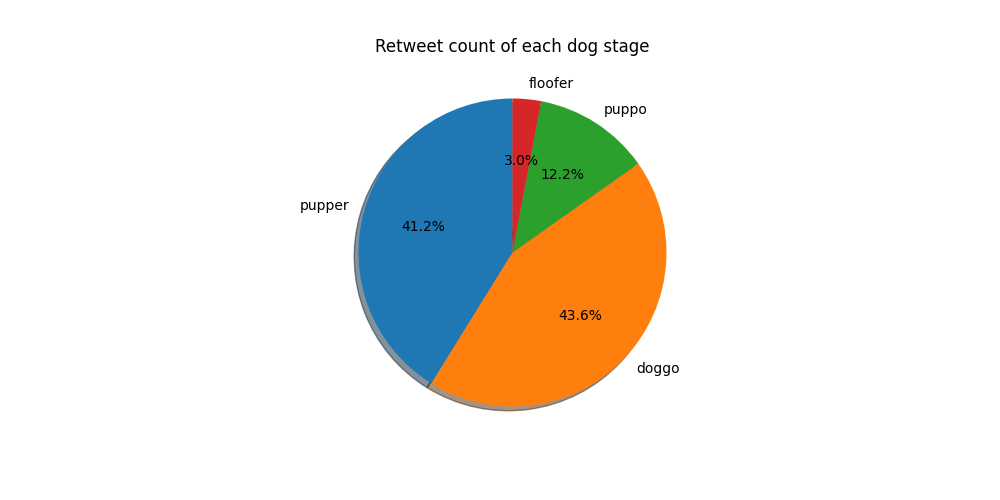

```python
Image(filename='Retweet count of each dog stage.png')
```

```python
print('Dog have most favorite count')
Image(url= 'https://pbs.twimg.com/media/C2tugXLXgAArJO4.jpg')
```

```
Dog have most favorite count
```

[figure not shown]

```python
print('Dog have most retweet count')
Image(url='https://pbs.twimg.com/ext_tw_video_thumb/744234667679821824/pu/img/1GaWmtJtdqzZV7jy.jpg')
```

```
Dog have most retweet count
```

[figure not shown]

### These findings are further supported by the attached photos, where the dogs with the highest favorite and retweet counts predominantly belong to the young, short-haired category. Thus, the visual evidence aligns with the observations deduced from the pie charts, reinforcing our initial conclusions.

# During the week, which day is the peak time when users post about their dogs? That is: in the sample, which day during the week has the most users posting with ‘WeRateDogs’？

### However, if a more precise determination of optimal ad delivery timing is desired, a more in-depth analysis can be performed by considering a 24-hour time frame. By scrutinizing the specific periods during which tweets were published, we can uncover valuable insights into the most opportune moments for content dissemination. Such a detailed investigation can enhance our understanding of the ideal timing to maximize the reach and impact of advertising efforts.

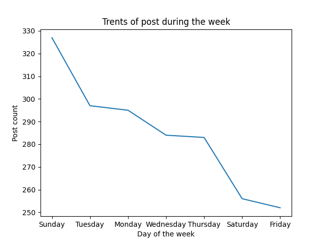

```python
Image(filename='Trents of post during the week.png')
```